# Reading Comprehension

```r
#Play the above chunk and this one in your Console to access the data
View(Baumann)
?Baumann
```

### Background

“This study investigated the effectiveness of explicit instruction in ‘think aloud’ as a means to promote elementary students’ comprehension monitoring abilities” [(Baumann & Jones, 1992)](http://jlr.sagepub.com/content/24/2/143.full.pdf).

Details of the Study (click to view)

In short, this study was done to see if there are better methods out there for helping students reading comprehension. This is important because if the education system can find better methods of improving reading comprehension, then they will help students be better prepared for higher education. The study compared the traditional teaching method with two other innovative methods to see if there was any difference in reading comprehension scores in a set of different tests.

### Data and Hypothesis

With the given data from the research study below, it was determined that the most accurate results could be obtained by running a Kruskal-Wallis test on Post Test 3, since it was a comprehensive test at the end of the year as well as a widely recognized test. Thus the null hypothesis for this test is that all groups are from the same distribution, and the alternative is that at least one group’s distribution is stochastically different than the others.

$$H_o: \text{All samples are from the same distribution.}$$

$$H_a: \text{At least one samples distribution is stochastically different.}$$

|  | group | pretest.1 | pretest.2 | post.test.1 | post.test.2 | post.test.3 |
| --- | --- | --- | --- | --- | --- | --- |
| 1 | Basal | 4 | 3 | 5 | 4 | 41 |
| 2 | Basal | 6 | 5 | 9 | 5 | 41 |
| 3 | Basal | 9 | 4 | 5 | 3 | 43 |
| 4 | Basal | 12 | 6 | 8 | 5 | 46 |
| 5 | Basal | 16 | 5 | 10 | 9 | 46 |
| 6 | Basal | 15 | 13 | 9 | 8 | 45 |
| 7 | Basal | 14 | 8 | 12 | 5 | 45 |
| 8 | Basal | 12 | 7 | 5 | 5 | 32 |
| 9 | Basal | 12 | 3 | 8 | 7 | 33 |
| 10 | Basal | 8 | 8 | 7 | 7 | 39 |

[output cut: 56 more lines]

## Kruskal-Wallis Test

To determine if there is sufficient enough evidence to reject the null hypothesis, a Kruskal-Wallis Rank Sum test was run on the “post.test.3” and “group” variables, with an $\alpha$ = 0.05 level of significance. The following results were obtained.

Kruskal-Wallis Rank Sum Test

| Test statistic | df | P value |
| --- | --- | --- |
| 9.632 | 2 | 0.0081 * * |

The table above shows that a p value of 0.0081 was obtained from the test, which is very significant. Thus there is sufficient evidence to reject the null hypothesis and accept the alternative, which means that at least one of the sample distributions is stochastically different.

## Graphical and Numerical Summaries

Because there was sufficient evidence to reject the null hypothesis, the boxplot and numerical summary below can be trusted.

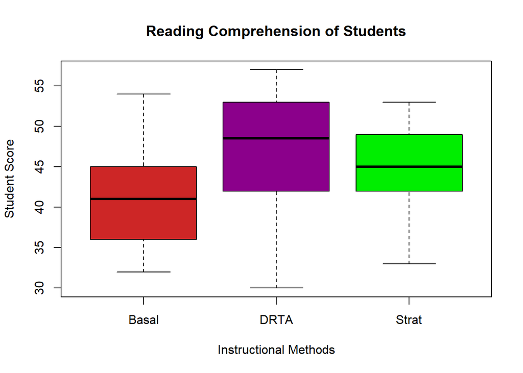

| group | min | Q1 | median | Q3 | max | mean | sd | n | missing |
| --- | --- | --- | --- | --- | --- | --- | --- | --- | --- |
| Basal | 32 | 36.75 | 41 | 45 | 54 | 41.05 | 5.636 | 22 | 0 |
| DRTA | 30 | 42.25 | 48.5 | 52.25 | 57 | 46.73 | 7.388 | 22 | 0 |
| Strat | 33 | 42 | 45 | 48.75 | 53 | 44.27 | 5.767 | 22 | 0 |

Both the box plot and numerical summary show that there is a difference in means and medians of student scores between all of the groups, and that one experimental method was more effective than the others.